# Vtuber Superchat Data Analysis - Hololive Charts

If you want to follow along, the associated files are hosted [here](https://github.com/neptunia/vtubers-data-science).

## The main data science process can be found [here](https://neptunia.github.io/vtubers-data-science/).

## Skip to here for charts. The following part is the code to set up the charts.

```python
# all the imports

from chat_downloader import ChatDownloader
from api_keys import *
import numpy as np
import math
import pandas as pd
import requests
from pandas.plotting import scatter_matrix
import matplotlib.pyplot as plt
import matplotlib.dates as mdates
from datetime import datetime
from dateutil import parser
import seaborn as sns
from scipy import stats
```

```python
# dataframe will have columns:
# channel name | channel id | video name | video id | description | publishedAt | video start time | video end time |
# video length | # superchats | $ superchats | localization | viewcount | tags (topicdetails) | timestamps of each superchat


c_names = pd.read_csv("vtuber_channels.csv", names=["vtuber_name", "affiliation", "channel_id"]);
df = pd.DataFrame(columns = ['channel_name', 'channel_id', 'video_name', 'video_id', 'description', 'published_at',
                             'video_start_time', 'video_end_time', 'video_length', 'num_superchats', 'val_superchats',
                            'locale', 'viewcount', 'tags', 'timestamps']);

c_names.head()
```

|  | vtuber_name | affiliation | channel_id |
| --- | --- | --- | --- |
| 0 | shirakami_fubuki | hololive | UCdn5BQ06XqgXoAxIhbqw5Rg |
| 1 | tokino_sora | hololive | UCp6993wxpyDPHUpavwDFqgg |
| 2 | haachama | hololive | UC1CfXB_kRs3C-zaeTG3oGyg |
| 3 | natsuiro_matsuri | hololive | UCQ0UDLQCjY0rmuxCDE38FGg |
| 4 | minato_aqua | hololive | UC1opHUrw8rvnsadT-iGp7Cg |

```python
c_names = pd.read_hdf("./h5s/vtubers.h5")

# let's sort it by subs count (ascending)
c_names["subs_count"] = pd.to_numeric(c_names["subs_count"])
c_names = c_names.sort_values(by=['subs_count'], ignore_index=True)
c_names.head()
```

|  | vtuber_name | affiliation | channel_id | subs_count | views_count | videos_count | country_loc |
| --- | --- | --- | --- | --- | --- | --- | --- |
| 0 | deisu_aruran | holostars | UCKeAhJvy8zgXWbh9duVjIaQ | 98400 | 3140315 | 610 | JP |
| 1 | peanut_kun | independent | UCmgWMQkenFc72QnYkdxdoKA | 111000 | 22847740 | 266 | JP |
| 2 | kageyama_shien | holostars | UChSvpZYRPh0FvG4SJGSga3g | 112000 | 3388583 | 258 | JP |
| 3 | tomoshika_hikasa | voms | UC3vzVK_N_SUVKqbX69L_X4g | 142000 | 6108838 | 201 | JP |
| 4 | yukoku_roberu | holostars | UCANDOlYTJT7N5jlRC3zfzVA | 166000 | 7847131 | 719 | JP |

# Data Management + Representation

Well, we now have all of the data we need to conduct our studies on, but a lot of it is not yet ready to work with. For example, the video start and end times are given in [ISO8601](https://en.wikipedia.org/wiki/ISO_8601) format strings (with a T between the date and the time, and a Z indicating that the time zone is UTC+0. We can't immediately work with these strings and need to change them to datetime objects first. We also need to do the same with the superchat timestamps, which are given as timestamps in microseconds. We need to also change those to datetimes.

Since this part is run separately from the previous ones (so that we don't need to do that gruesome data collection again), we start by opening the file we saved earlier.

```python
joined = pd.read_hdf('h5s/joined.h5')
joined['timestamps'] = joined['timestamps'].apply(lambda x: [datetime.utcfromtimestamp(i/1000000) for i in x])
joined['published_at'] = joined['published_at'].apply(parser.isoparse)
joined["video_start_time"] = joined["video_start_time"].apply(parser.isoparse)
joined["video_end_time"] = joined["video_end_time"].apply(parser.isoparse)
for ind, row in joined.iterrows():
    joined.at[ind, "video_length"] = (row["video_end_time"]-row["video_start_time"])/np.timedelta64(1,'m')

joined["viewcount"] = pd.to_numeric(joined["viewcount"])
joined["video_length"] = pd.to_numeric(joined["video_length"])
joined["num_superchats"] = pd.to_numeric(joined["num_superchats"])

joined["stream_start_hour"] = joined.apply(lambda row: row["video_start_time"].hour, axis=1)
joined["stream_end_hour"] = joined.apply(lambda row: row["video_end_time"].hour, axis=1)
joined["is_gaming"] = joined.apply(lambda row: int('game' in ''.join(row["tags"])), axis=1)
joined["average_superchat_value"] = joined.apply(lambda row: row["val_superchats"]/row["num_superchats"] if row["num_superchats"] > 0 else 0, axis=1)


def vtuber_to_ordinal(vt):
    return c_names[c_names['vtuber_name'] == vt].index[0]

def affiliation_to_ordinal(vt):
    ordinal_list = ["independent", "voms", "holostars", "nijisanji", "hololive_id", "hololive_en", "hololive"]
    st = c_names[c_names['vtuber_name'] == vt].iloc[0].affiliation
    return ordinal_list.index(st)

joined["vtuber_ordinal"] = joined.apply(lambda row: vtuber_to_ordinal(row["channel_name"]), axis=1)
joined["affiliation_ordinal"] = joined.apply(lambda row: affiliation_to_ordinal(row["channel_name"]), axis=1)

joined.head()
```

|  | channel_name | channel_id | video_name | video_id | description | published_at | video_start_time | video_end_time | video_length | num_superchats | ... | viewcount | tags | timestamps | game_name | stream_start_hour | stream_end_hour | is_gaming | average_superchat_value | vtuber_ordinal | affiliation_ordinal |
| --- | --- | --- | --- | --- | --- | --- | --- | --- | --- | --- | --- | --- | --- | --- | --- | --- | --- | --- | --- | --- | --- |
| 0 | shirakami_fubuki | UCdn5BQ06XqgXoAxIhbqw5Rg | 【#FOXDEMON】クシャルダオラの時間だゴラァ！！！【ホロライブプロダクション/白上フブ... | 14YQQoswvu0 | #FOXDEMON モンハンコラボです\n\n荒咬オウガ\nYoutube: @Oga Ch... | 2021-04-28 15:41:51+00:00 | 2021-04-28 13:00:12+00:00 | 2021-04-28 15:21:21+00:00 | 141.150000 | 8 | ... | 78525 | [Action_game, Role-playing_video_game, Strateg... | [2021-04-28 13:06:56.872040, 2021-04-28 13:23:... | Monster Hunter Rise | 13 | 15 | 1 | 3.917635 | 45 | 6 |
| 1 | shirakami_fubuki | UCdn5BQ06XqgXoAxIhbqw5Rg | 【SONG】夕方の貴重な歌枠。【ホロライブ/白上フブキ】 | -p8DUBvsMwc | ホロライブ所属の白上フブキです\nお久しぶりに歌っていきます✨✨\n\n歌っちゃ王\nhtt... | 2021-04-28 11:20:11+00:00 | 2021-04-28 08:57:39+00:00 | 2021-04-28 11:09:31+00:00 | 131.866667 | 117 | ... | 165992 | [Entertainment, Film] | [2021-04-28 08:52:57.092673, 2021-04-28 09:00:... | N/A | 8 | 11 | 0 | 7.203043 | 45 | 6 |
| 2 | shirakami_fubuki | UCdn5BQ06XqgXoAxIhbqw5Rg | 【#バカタレ共】おきろ！！！！狩りの時間だ！！！【ホロライブ/白上フブキ/角巻わため/不知火... | 2XH7EkqTWI8 | バカタレ共です。\nモンハンアプデ！！！\n\n■不知火フレア\n@Flare Ch. 不知... | 2021-04-28 03:15:29+00:00 | 2021-04-28 00:00:49+00:00 | 2021-04-28 02:52:30+00:00 | 171.683333 | 28 | ... | 185481 | [Action_game, Role-playing_video_game, Strateg... | [2021-04-27 22:27:24.007195, 2021-04-28 00:02:... | Monster Hunter | 0 | 2 | 1 | 24.612741 | 45 | 6 |
| 3 | shirakami_fubuki | UCdn5BQ06XqgXoAxIhbqw5Rg | 【#バカタレ共】モンスターハンター スペシャルプログラム 同時視聴!!【ホロライブ/白上フブ... | v3IYT5p79Fg | バカタレ共です。\n\n「モンスターハンター スペシャルプログラム 2021.4.27」\n... | 2021-04-27 14:25:41+00:00 | 2021-04-27 13:46:33+00:00 | 2021-04-27 14:20:20+00:00 | 33.783333 | 14 | ... | 114674 | [Entertainment, Film] | [2021-04-27 13:50:17.603994, 2021-04-27 13:51:... | N/A | 13 | 14 | 0 | 6.882685 | 45 | 6 |
| 4 | shirakami_fubuki | UCdn5BQ06XqgXoAxIhbqw5Rg | 【#from1st 】開催まであと１ヶ月!!見どころや未公開情報も解禁!!【ホロライブ１期生】 | hKdM0ldOJlE | ホロライブ1期生の3周年記念ライブ「from 1st」\n2021年 5月 28日（金）\n... | 2021-04-27 12:03:13+00:00 | 2021-04-27 10:58:11+00:00 | 2021-04-27 11:57:47+00:00 | 59.600000 | 3 | ... | 75277 | [Entertainment, Film] | [2021-04-27 11:02:03.777833, 2021-04-27 11:02:... | N/A | 10 | 11 | 0 | 4.990000 | 45 | 6 |

5 rows × 22 columns

# CHARTS

## Correlation between time of day and superchats

All times are in UTC. Add 9 hours to get JST.

```
{15: 26023, 11: 7578, 2: 937, 14: 23381, 10: 5298, 13: 20404, 17: 12136, 3: 3271, 6: 3180, 5: 3278, 12: 21781, 9: 4314, 8: 1790, 16: 19000, 19: 6570, 7: 2122, 1: 231, 0: 1498, 20: 3197, 18: 9142, 4: 1301, 21: 2234, 23: 2250, 22: 2099}
```

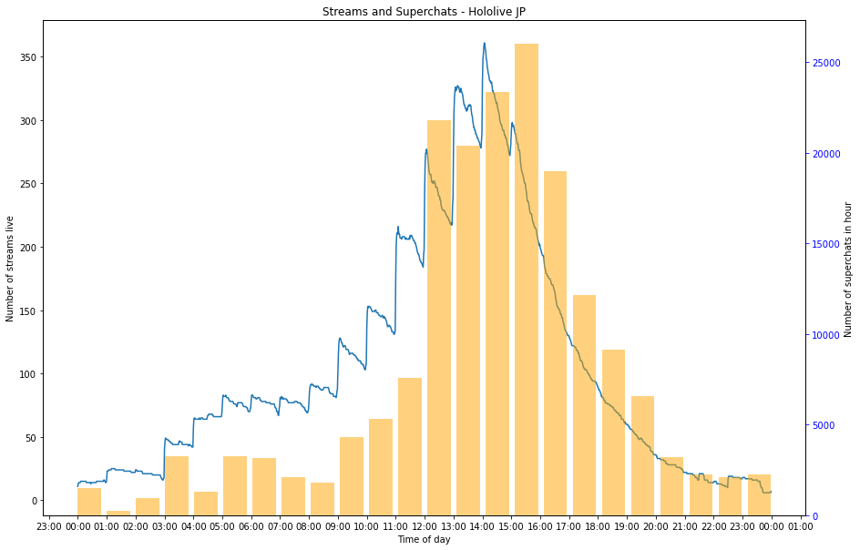

```python
from datetime import time,date, timedelta
# bar chart for all superchats
datetimes = {}
schats = {}
# 00:00 to 23:59


# HOLOLIVE (JP) ONLY VTUBERS
for ind, row in joined.loc[joined['affiliation_ordinal'].isin([6])].iterrows():

    ct = row["video_start_time"]
    while ct <= row["video_end_time"]:
        # use a random fake date because matplotlib needs an actual date to plot time series
        t = datetime.combine(date(2000, 1, 1),
                          ct.replace(second=0).time())
        if t in datetimes:
            datetimes[t]+= 1
        else:
            datetimes[t]=1
        ct += timedelta(minutes=1)


    for i in row["timestamps"]:
        t1 = ct.hour
        if t1 in schats:
            schats[t1]+= 1
        else:
            schats[t1]=1
#print(datetimes)
print(schats)
x,y = zip(*sorted(datetimes.items()))
x2,y2 = zip(*sorted(schats.items()))
fig, ax = plt.subplots(figsize=(15, 10));
ax.plot(x,y)

ax2 = ax.twiny().twinx()
ax2.set_xticks([])
ax2.tick_params('y', colors='b')
#ax2.set_ylim(top=8000)
ax2.bar(x2, y2, color='orange', alpha=0.5)

xfmt = mdates.DateFormatter('%H:%M')
ax.set_title("Streams and Superchats - Hololive JP")
ax.set_xlabel("Time of day")
ax.set_ylabel("Number of streams live")
ax2.set_ylabel("Number of superchats in hour")
ax.xaxis.set_major_locator(mdates.HourLocator())
ax.xaxis.set_major_formatter(xfmt)
```

# HOLOLIVE JP CHARTS

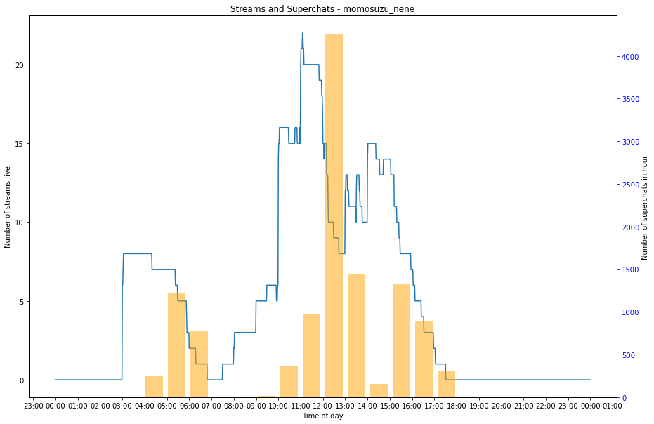

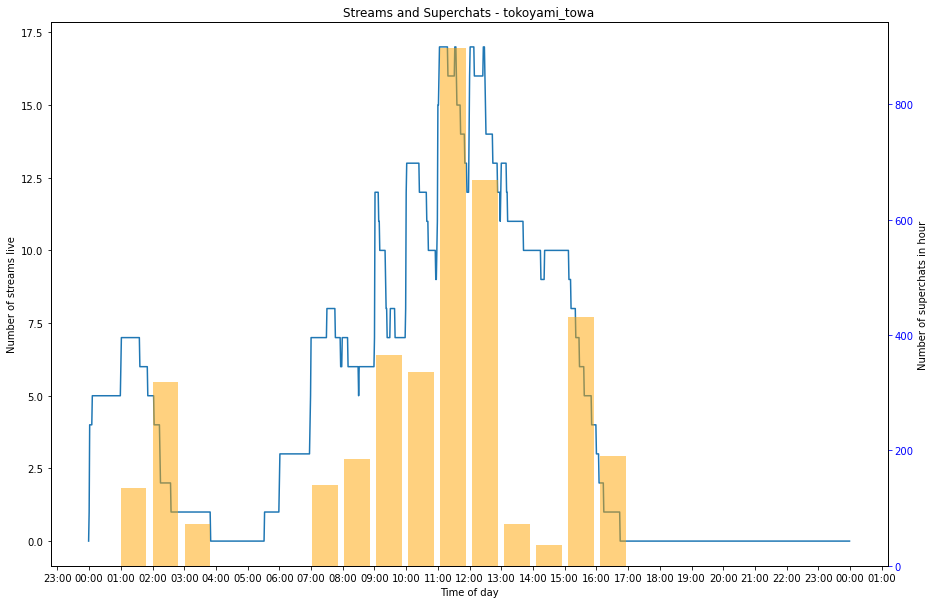

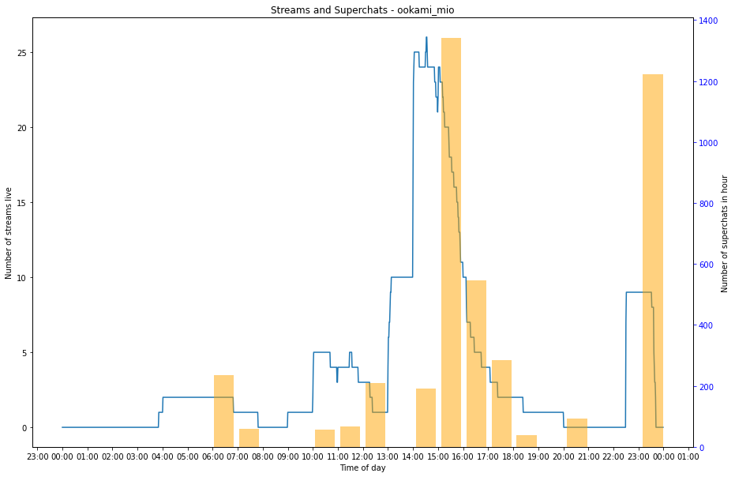

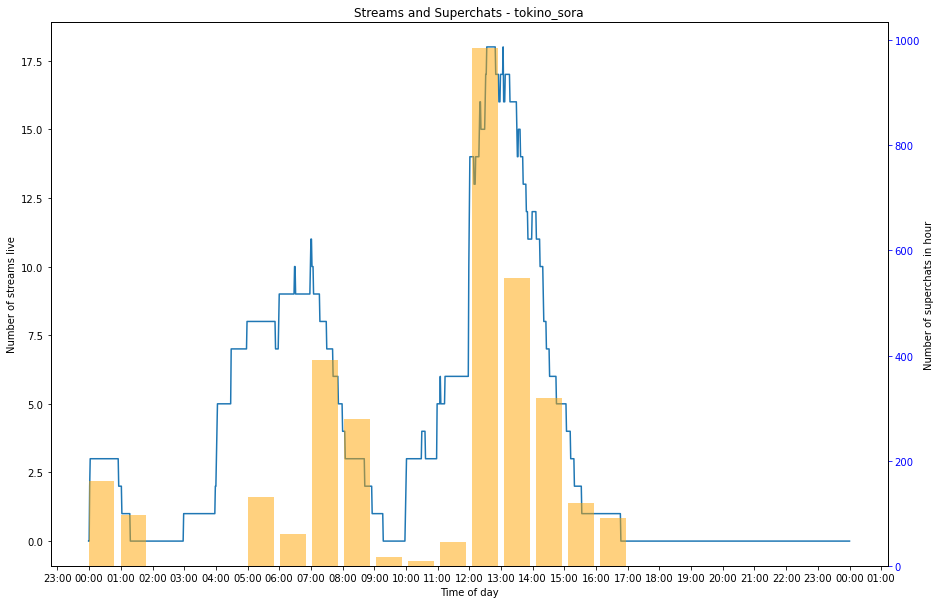

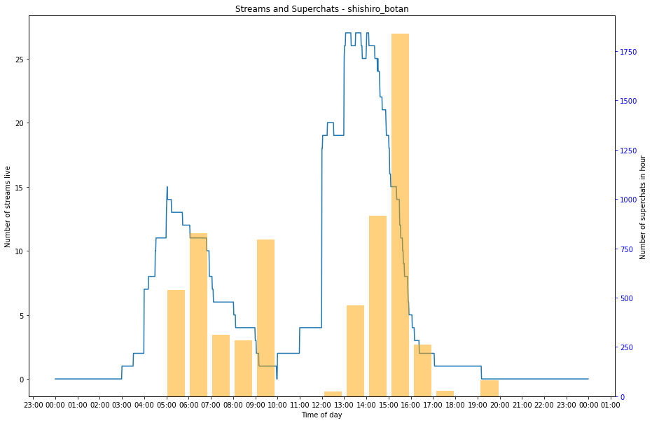

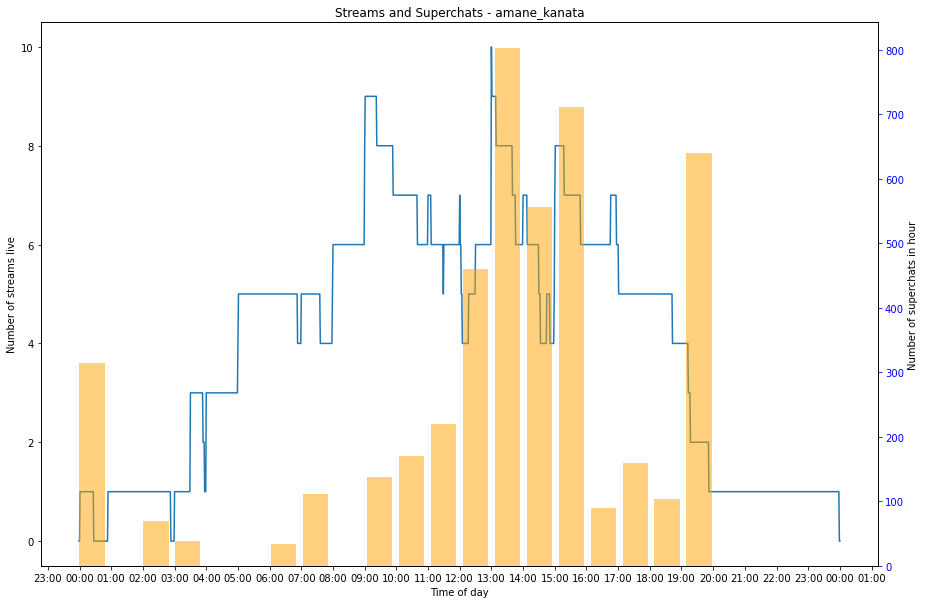

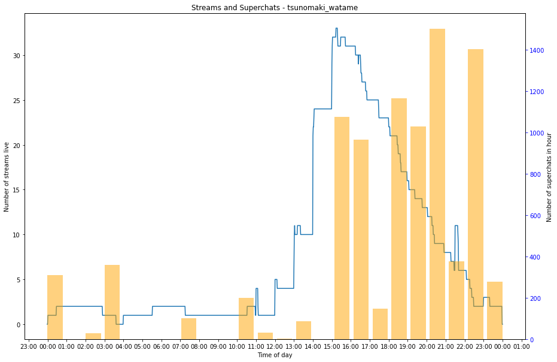

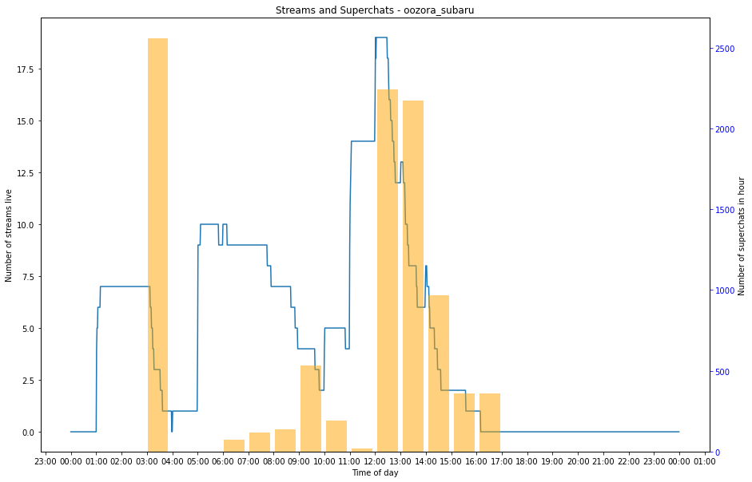

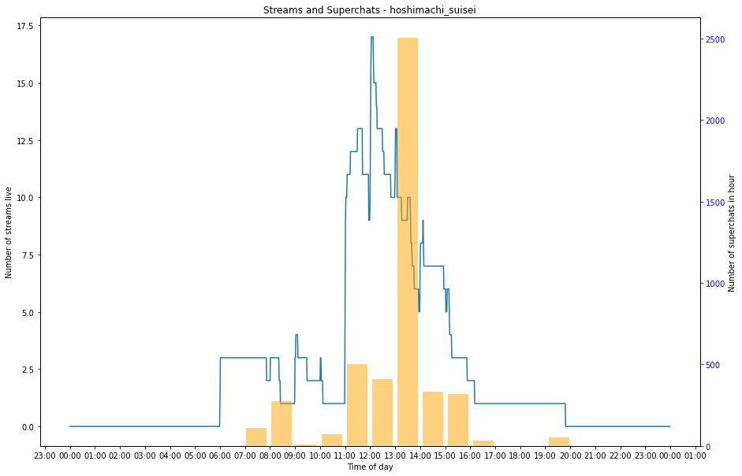

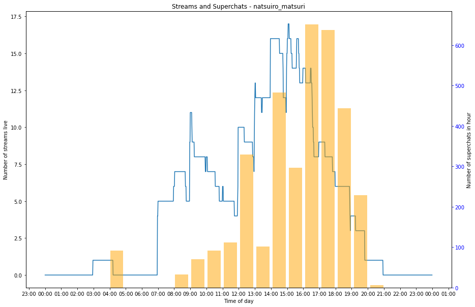

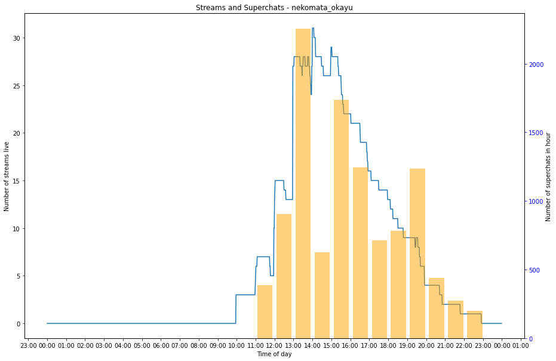

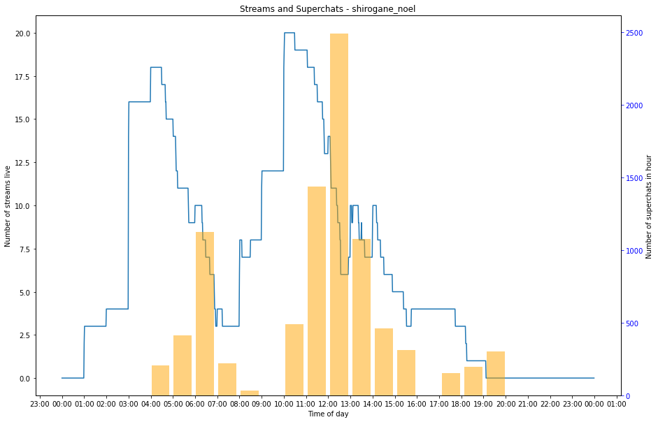

[8 more figures not shown]

```python
for vtname in c_names.loc[c_names["affiliation"]=="hololive"]["vtuber_name"]:
    datetimes = {}
    schats = {}
    # 00:00 to 23:59

    for i in range(24):
        schats[i] = 0


    # HOLOLIVE (JP) ONLY VTUBERS
    for ind, row in joined.loc[joined['channel_name']==vtname].iterrows():
        datetimes[datetime.combine(date(2000, 1, 1),time(0,0))] = 0
        datetimes[datetime.combine(date(2000, 1, 1),time(23,59))] = 0
        ct = row["video_start_time"]
        while ct <= row["video_end_time"]:
            # use a random fake date because matplotlib needs an actual date to plot time series
            t = datetime.combine(date(2000, 1, 1),
                              ct.replace(second=0).time())
            if t in datetimes:
                datetimes[t]+= 1
                temp = t - timedelta(minutes=1)
                if temp not in datetimes:
                    datetimes[temp] = 0
                temp = t + timedelta(minutes=1)
                if temp not in datetimes:
                    datetimes[temp] = 0
            else:
                datetimes[t]=1
                temp = t - timedelta(minutes=1)
                if temp not in datetimes:
                    datetimes[temp] = 0
                temp = t + timedelta(minutes=1)
                if temp not in datetimes:
                    datetimes[temp] = 0
            ct += timedelta(minutes=1)


        for i in row["timestamps"]:
            t1 = ct.hour
            if t1 in schats:
                schats[t1]+= 1
            else:
                schats[t1]=1
    #print(datetimes)
    #print(schats)
    x,y = zip(*sorted(datetimes.items()))
    x2,y2 = zip(*sorted(schats.items()))
    fig, ax = plt.subplots(figsize=(15, 10));
    ax.plot(x,y)

    ax2 = ax.twiny().twinx()
    ax2.set_xticks([])
    ax2.tick_params('y', colors='b')
    #ax2.set_ylim(top=8000)
    ax2.bar(x2, y2, color='orange', alpha=0.5)

    xfmt = mdates.DateFormatter('%H:%M')
    ax.set_title("Streams and Superchats - {0}".format(vtname))
    ax.set_xlabel("Time of day")
    ax.set_ylabel("Number of streams live")
    ax2.set_ylabel("Number of superchats in hour")
    ax.xaxis.set_major_locator(mdates.HourLocator())
    ax.xaxis.set_major_formatter(xfmt)
```

# HOLOLIVE EN CHARTS

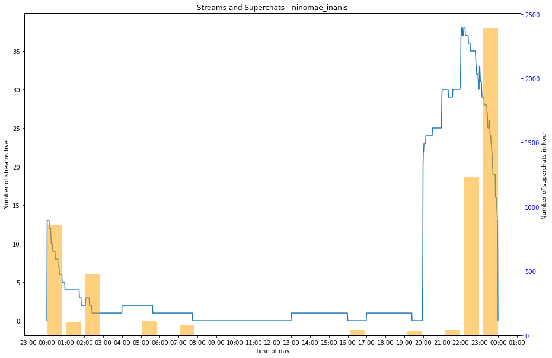

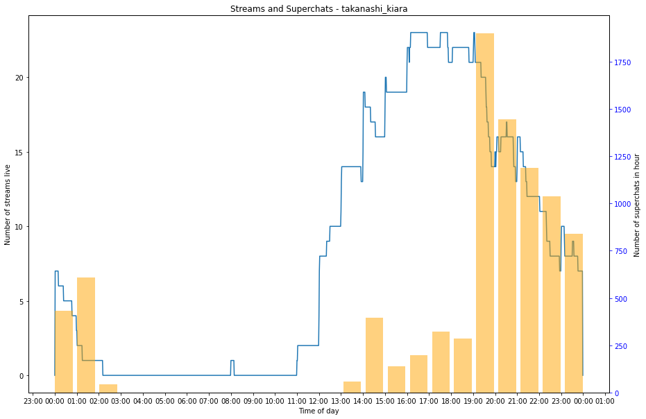

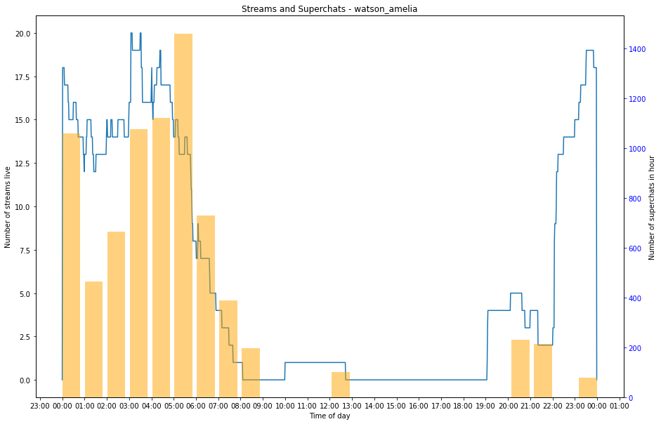

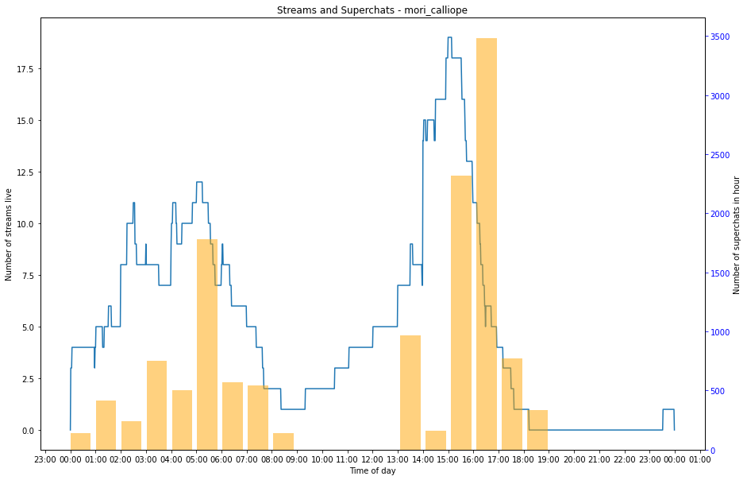

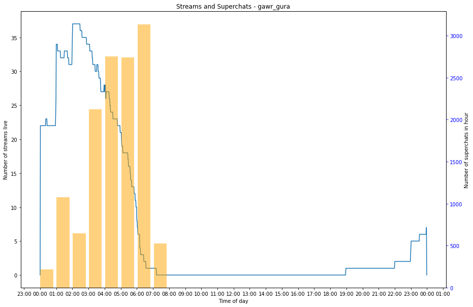

```python
for vtname in c_names.loc[c_names["affiliation"]=="hololive_en"]["vtuber_name"]:
    datetimes = {}
    schats = {}
    # 00:00 to 23:59

    for i in range(24):
        schats[i] = 0


    # HOLOLIVE (JP) ONLY VTUBERS
    for ind, row in joined.loc[joined['channel_name']==vtname].iterrows():
        datetimes[datetime.combine(date(2000, 1, 1),time(0,0))] = 0
        datetimes[datetime.combine(date(2000, 1, 1),time(23,59))] = 0
        ct = row["video_start_time"]
        while ct <= row["video_end_time"]:
            # use a random fake date because matplotlib needs an actual date to plot time series
            t = datetime.combine(date(2000, 1, 1),
                              ct.replace(second=0).time())
            if t in datetimes:
                datetimes[t]+= 1
                temp = t - timedelta(minutes=1)
                if temp not in datetimes and temp.time() != time(23, 59):
                    datetimes[temp] = 0
                temp = t + timedelta(minutes=1)
                if temp not in datetimes and temp.time() != time(0, 0):
                    datetimes[temp] = 0
            else:
                datetimes[t]=1
                temp = t - timedelta(minutes=1)
                if temp not in datetimes and temp.time() != time(23, 59):
                    datetimes[temp] = 0
                temp = t + timedelta(minutes=1)
                if temp not in datetimes and temp.time() != time(0, 0):
                    datetimes[temp] = 0
            ct += timedelta(minutes=1)


        for i in row["timestamps"]:
            t1 = ct.hour
            if t1 in schats:
                schats[t1]+= 1
            else:
                schats[t1]=1
    #print(datetimes)
    #print(schats)
    x,y = zip(*sorted(datetimes.items()))
    x2,y2 = zip(*sorted(schats.items()))
    fig, ax = plt.subplots(figsize=(15, 10));
    ax.plot(x,y)

    ax2 = ax.twiny().twinx()
    ax2.set_xticks([])
    ax2.tick_params('y', colors='b')
    #ax2.set_ylim(top=8000)
    ax2.bar(x2, y2, color='orange', alpha=0.5)

    xfmt = mdates.DateFormatter('%H:%M')
    ax.set_title("Streams and Superchats - {0}".format(vtname))
    ax.set_xlabel("Time of day")
    ax.set_ylabel("Number of streams live")
    ax2.set_ylabel("Number of superchats in hour")
    ax.xaxis.set_major_locator(mdates.HourLocator())
    ax.xaxis.set_major_formatter(xfmt)
```

## HOLOLIVE ID CHARTS

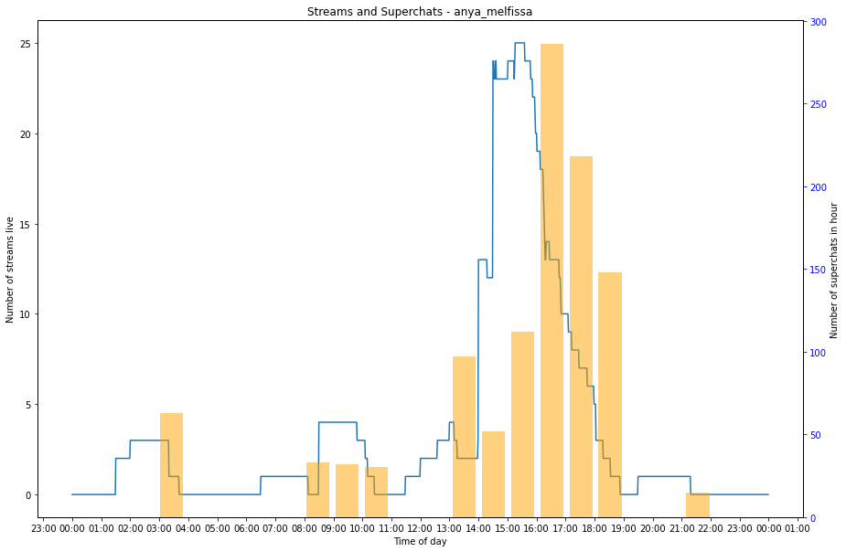

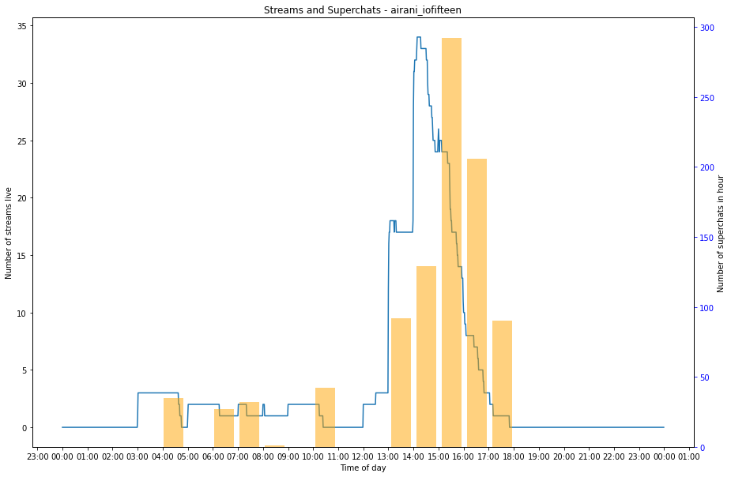

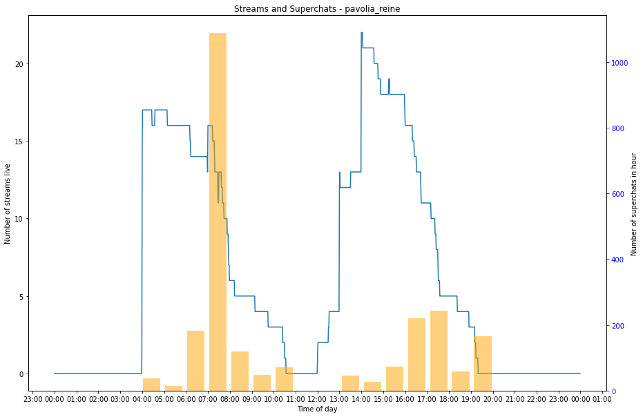

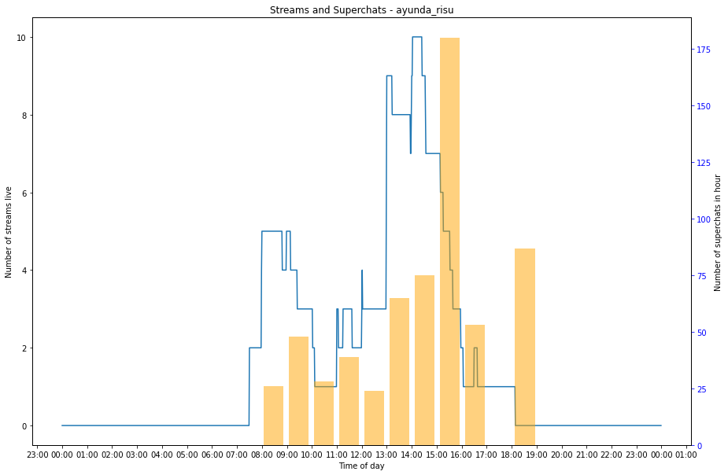

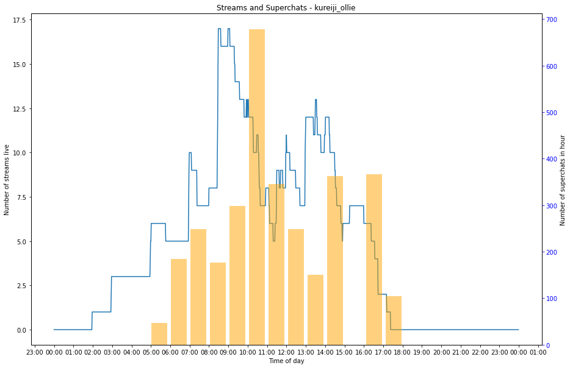

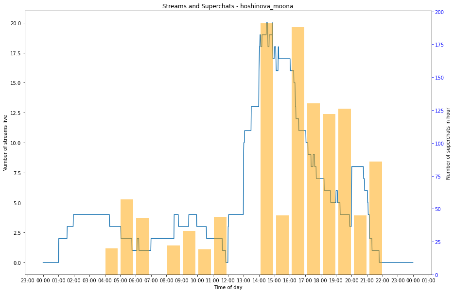

```python
for vtname in c_names.loc[c_names["affiliation"]=="hololive_id"]["vtuber_name"]:
    datetimes = {}
    schats = {}
    # 00:00 to 23:59

    for i in range(24):
        schats[i] = 0


    # HOLOLIVE (JP) ONLY VTUBERS
    for ind, row in joined.loc[joined['channel_name']==vtname].iterrows():
        datetimes[datetime.combine(date(2000, 1, 1),time(0,0))] = 0
        datetimes[datetime.combine(date(2000, 1, 1),time(23,59))] = 0
        ct = row["video_start_time"]
        while ct <= row["video_end_time"]:
            # use a random fake date because matplotlib needs an actual date to plot time series
            t = datetime.combine(date(2000, 1, 1),
                              ct.replace(second=0).time())
            if t in datetimes:
                datetimes[t]+= 1
                temp = t - timedelta(minutes=1)
                if temp not in datetimes and temp.time() != time(23, 59):
                    datetimes[temp] = 0
                temp = t + timedelta(minutes=1)
                if temp not in datetimes and temp.time() != time(0, 0):
                    datetimes[temp] = 0
            else:
                datetimes[t]=1
                temp = t - timedelta(minutes=1)
                if temp not in datetimes and temp.time() != time(23, 59):
                    datetimes[temp] = 0
                temp = t + timedelta(minutes=1)
                if temp not in datetimes and temp.time() != time(0, 0):
                    datetimes[temp] = 0
            ct += timedelta(minutes=1)


        for i in row["timestamps"]:
            t1 = ct.hour
            if t1 in schats:
                schats[t1]+= 1
            else:
                schats[t1]=1
    #print(datetimes)
    #print(schats)
    x,y = zip(*sorted(datetimes.items()))
    x2,y2 = zip(*sorted(schats.items()))
    fig, ax = plt.subplots(figsize=(15, 10));
    ax.plot(x,y)

    ax2 = ax.twiny().twinx()
    ax2.set_xticks([])
    ax2.tick_params('y', colors='b')
    #ax2.set_ylim(top=8000)
    ax2.bar(x2, y2, color='orange', alpha=0.5)

    xfmt = mdates.DateFormatter('%H:%M')
    ax.set_title("Streams and Superchats - {0}".format(vtname))
    ax.set_xlabel("Time of day")
    ax.set_ylabel("Number of streams live")
    ax2.set_ylabel("Number of superchats in hour")
    ax.xaxis.set_major_locator(mdates.HourLocator())
    ax.xaxis.set_major_formatter(xfmt)
```

### Time of Day and Superchats: Summary

Although we did not do any quantitative analyses here nor find anything groundbreaking, we did corroborate some concepts that might have seemed like common sense.

- There is a spike in streams on the hour, because that's when streams are scheduled
- Late evening is "prime time" for Vtubers
- Fewer superchats happen during the work day (afternoon)
- More superchats happen during the late evening

### Possible Future Work

While we qualitatively asserted that the shape of the "superchats per hour" distribution was similar but different to the "streams live at any time" distribution, we did not back this up with numbers. In future work, one could use the 2-sample [Kolmogorov-Smirnov test](https://en.wikipedia.org/wiki/Kolmogorov%E2%80%93Smirnov_test) ([another link for more info](https://www.spss-tutorials.com/spss-kolmogorov-smirnov-test-for-normality/)) to test if the two datasets have the same shape.

```
a =  0.06631264243217902
k =  0.7581418841466804
```

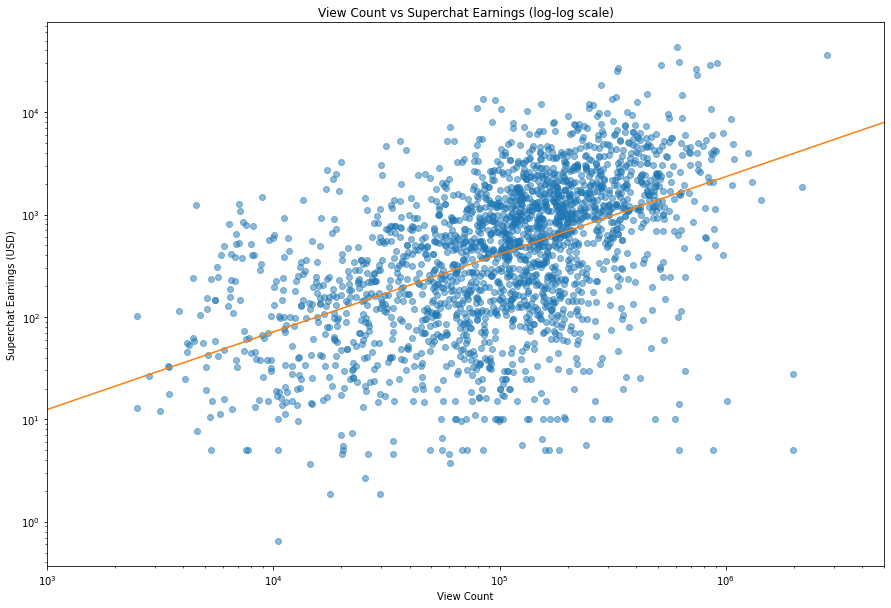

```python
fig, ax = plt.subplots(figsize=(15, 10))
plt.xlim([10**3, 5*10**6])
ax.plot(joined["viewcount"] ,joined["val_superchats"], 'o', alpha=0.5)
ax.set_yscale('log')
ax.set_xscale('log')

ax.set_xlabel("View Count")
ax.set_ylabel("Superchat Earnings (USD)")
ax.set_title("View Count vs Superchat Earnings (log-log scale)")
x = np.array(range(10**3, 10**7, 5))
# convert the slope and intercept to the relevant values in the right places
print("a = ", math.e**intercept)
print("k = ", slope)
ax.plot(x, (math.e**intercept)*x**slope);

plt.show()
```

Anyways, from our basic regression, it seems like superchat earnings can be roughly modelled by the equation:

$y = 0.0663126 x^{0.758142}$

Where x is the number of viewers and y is the superchat revenue.

## Video game streams - better or worse?

Next, let's see if video game streams do better or worse than this average.

```
Regression from scipy y=mx+b:
y = 0.957162 x + -5.281012
p-value: 8.104118e-133
r-value: 0.631815
standard error: 0.034170
a =  0.005087282402439689
k =  0.9571623123318653
```

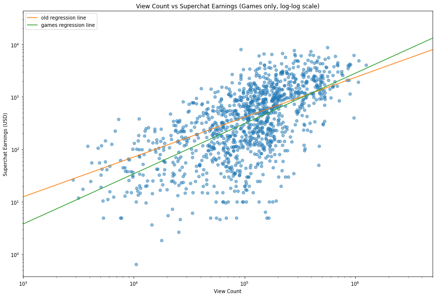

```python
games_only = joined.loc[joined['game_name'] != 'N/A']
temp_df = games_only[["viewcount","val_superchats"]]
temp_df = temp_df[temp_df['val_superchats']>0]
temp_df['viewcount'] = temp_df['viewcount'].apply(math.log)
temp_df['val_superchats'] = temp_df['val_superchats'].apply(math.log)

slope_g, intercept_g, r_value_g, p_value_g, std_err_g = stats.linregress(temp_df["viewcount"],temp_df["val_superchats"])
print('Regression from scipy y=mx+b: \ny = %f x + %f'%(slope_g, intercept_g))
print('p-value: %e'%(p_value_g))
print('r-value: %f'%(r_value_g))
print('standard error: %f'%(std_err_g))


fig, ax = plt.subplots(figsize=(15, 10))
plt.xlim([10**3, 5*10**6])
ax.plot(games_only["viewcount"] ,games_only["val_superchats"], 'o', alpha=0.5)
ax.set_yscale('log')
ax.set_xscale('log')

ax.set_xlabel("View Count")
ax.set_ylabel("Superchat Earnings (USD)")
ax.set_title("View Count vs Superchat Earnings (Games only, log-log scale)")
x = np.array(range(10**3, 10**7, 5))
# convert the slope and intercept to the relevant values in the right places
print("a = ", math.e**intercept_g)
print("k = ", slope_g)
ax.plot(x, (math.e**intercept)*x**slope, color='C1', label="old regression line");
ax.plot(x, (math.e**intercept_g)*x**slope_g, color='C2', label="games regression line");
plt.legend(loc='upper left');


plt.show()
```

Interesting. The r-value is higher (giving us a $r^2 \approx 0.4$), implying that this regression is a better fit for this subset of data than our original regression line was for the entire dataset, but that's probably to be expected. Also, this regression line has a greater slope but lower intercept than the original regression. A possible hypothesis to explain this is that **in general people do not superchat as much on game streams**, as evidenced by the fact that most of the data points have fewer views than the intersection of the two regression lines. However, for popular games that a lot of people enjoy (and thus also watch), they are more willing to shell out money. Of course, checking whether this is the case or not is out of scope of this project.

```
1183
```

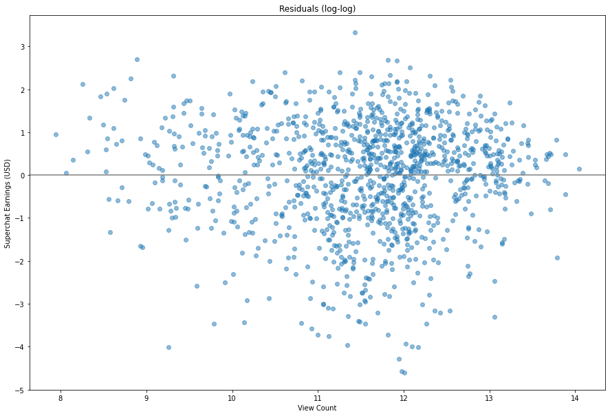

```python
print(len(temp_df))
fig, ax = plt.subplots(figsize=(15, 10))
residuals = []
for ind, row in temp_df.iterrows():
    residuals.append(row["val_superchats"] - slope_g*row["viewcount"]-intercept_g)
#print(residuals)
ax.plot(temp_df["viewcount"] ,residuals, 'o', alpha=0.5)
#plt.yscale('symlog')
ax.set_xlabel("View Count")
ax.set_ylabel("Superchat Earnings (USD)")
ax.set_title("Residuals (log-log)")
ax.axhline(color="gray")
plt.show()
```